# Giving a Thematic Touch to your Interactive Chart

data-visualization

Sometimes you need to express yourself.

Joshua Kunst http://jkunst.com/  
03-03-2017

## Preliminars

Usually (mainly at work) I made a chart and when I present it nobody cares about the style, if the chart comes from an excel spreadsheet, paint or intercative chart, or colors, labels, font, or things I like to care. That’s sad for me but it’s fine: the data/history behind and how you present it is what matters. And surely I’m overreacting.

But hey! That’s not implies you only must do always clean chart or tufte style plots. Sometimes you can play with the topic of your chart and give some *thematic touch*.

The first example that come to my mind is the *Iraq’s bloody toll* visualization:

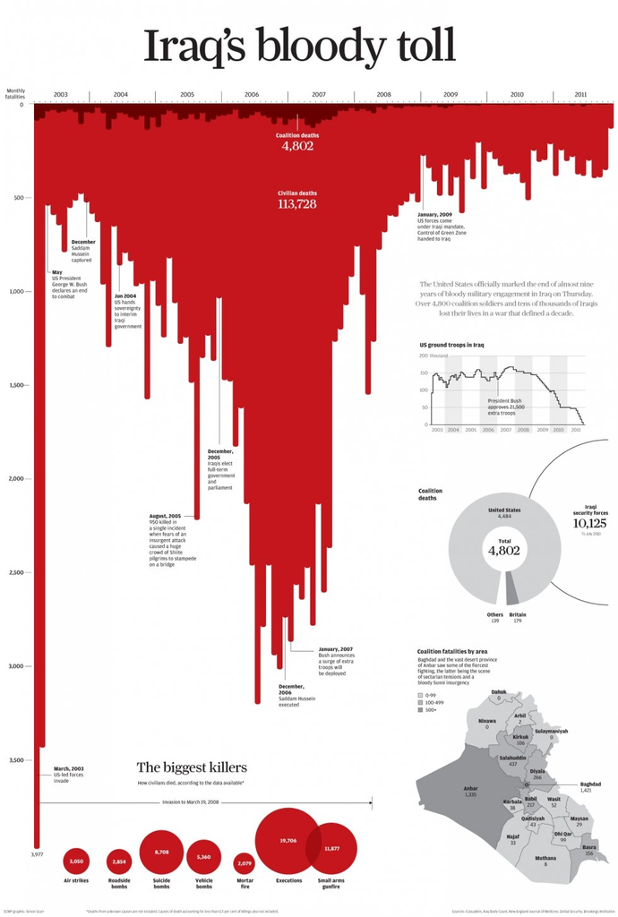

Iraq’s bloody toll

So. We’ll use some resources to try:

- Add some context of the topic before the viewer read something.
- Hopefully keep in the viewer’s memory :) in a *gooood* way.

Keeping the message intact, ie, don’t abuse adding many element so the user don’t lose the main point of the chart.

## Example I: Oil Spills

We can reuse the *bloody toll* effect, using with *Oil Spills* data.

The [ourworldindata.org](https://ourworldindata.org/oil-spills/) website have a descriptive study Max Roser.

> Max Roser (2016) - ‘Oil Spills’. Published online at OurWorldInData.org. Retrieved from: https://ourworldindata.org/oil-spills/ [Online Resource]

They start with:

> Over the past 4 decades - the time for which we have data - oil spills decreased dramatically. Although oil spills also happen on land, marine oil spills are considered more serious as the spilled oil is less containable

Let’s load the data and make the basic chart.

```
library(tidyverse)
library(jsonlite)

json <- read_lines("https://ourworldindata.org/wp-content/uploads/nvd3/nvd3_multiBarChart_Oil/multiBarChart_Oil.html")
json <- json[seq(
  which(str_detect(json, "var xxx")),
  first(which(str_detect(json, "\\}\\]\\;")))
)]

json <- fromJSON(str_replace_all(json, "var xxx = |;$", ""))
json <- transpose(json)

str(json)
```

```
List of 2
 $ :List of 2
  ..$ values:'data.frame':  43 obs. of  2 variables:
  .. ..$ x: num [1:43] 0.00 3.16e+10 6.31e+10 9.47e+10 1.26e+11 ...
  .. ..$ y: int [1:43] 30 14 27 31 27 20 26 16 23 32 ...
  ..$ key   : chr ">700 Tonnes"
 $ :List of 2
  ..$ values:'data.frame':  43 obs. of  2 variables:
  .. ..$ x: num [1:43] 0.00 3.16e+10 6.31e+10 9.47e+10 1.26e+11 ...
  .. ..$ y: int [1:43] 7 18 48 28 90 96 67 69 59 60 ...
  ..$ key   : chr "7-700 Tonnes"
```

```
dspills <- map_df(json, function(x) {
  df <- as.data.frame(x[["values"]])
  df$key <- x[["key"]]
  tbl_df(df)
  df
})

glimpse(dspills)
```

```
Rows: 86
Columns: 3
$ x   <dbl> 0.00000e+00, 3.15569e+10, 6.31138e+10, 9.46707e+10, 1...
$ y   <int> 30, 14, 27, 31, 27, 20, 26, 16, 23, 32, 13, 7, 4, 13,...
$ key <chr> ">700 Tonnes", ">700 Tonnes", ">700 Tonnes", ">700 To...
```

The data is ready. So we can make an staked area chart. I used *areaspline* here to make a *liquid* effect.

```
library(highcharter)

hcspills <- hchart(dspills, "areaspline", hcaes(x, y, group = "key")) %>%
  hc_plotOptions(series = list(stacking = "normal")) %>%
  hc_xAxis(type = "datetime") %>%
  hc_title(text = "Number of Oil Spills Over the Past 4 Decades")

hcspills
```

[interactive chart not shown]

Yay, the spills are decreasing over time. So we can do:

- Add a *deep sea* background.
- Reverse the `yAxis` to the give the *fall* effect.
- Add a dark colors to simulate the *oil*.
- Add the credits for give the *serious* (? ;) ) touch.

```
hcspills2 <- hcspills %>%
  hc_colors(c("#000000", "#222222")) %>%
  hc_title(align = "left", style = list(color = "black")) %>%
  hc_plotOptions(series = list(marker = list(enabled = FALSE))) %>%
  hc_tooltip(sort = TRUE, table = TRUE) %>%
  hc_legend(align = "right", verticalAlign = "top", layout = "horizontal") %>%
  hc_credits(
    enabled = TRUE,
    text = "Data from ITOPF.com",
    href = "http://www.itopf.com/knowledge-resources/data-statistics/statistics/"
  ) %>%
  hc_chart(
    divBackgroundImage = "https://images-na.ssl-images-amazon.com/images/I/71EUEG8orVL._SL1500_.jpg",
    backgroundColor = hex_to_rgba("white", 0.50)
  ) %>%
  hc_xAxis(
    opposite = TRUE,
    gridLineWidth = 0,
    title = list(text = "Time", style = list(color = "black")),
    lineColor = "black", tickColor = "black",
    labels = list(style = list(color = "black"))
    ) %>%
  hc_yAxis(
    reversed = TRUE,
    gridLineWidth = 0,
    lineWidth = 1,
    lineColor = "black",
    tickWidth = 1,
    tickLength = 10,
    tickColor = "black",
    title = list(text = "Oil Spills", style = list(color = "black")),
    labels = list(style = list(color = "black"))
    ) %>%
  hc_add_theme(hc_theme_elementary())
```

```
hcspills2
```

[interactive chart not shown]

## Example II: Winter Olympic Games

Here we will take the data and chart the participating nations over the years.

```
library(rvest)

tables <- read_html("https://en.wikipedia.org/wiki/Winter_Olympic_Games") %>%
  html_table(fill = TRUE)

dgames <- tables[[6]]
dgames <- janitor::clean_names(dgames)
dgames <- tbl_df(dgames)

dgames <- mutate_if(dgames, is.character, str_trim)

dgames <- filter(dgames, !no %in% c("1940", "1944"))
dgames <- filter(dgames, !year %in% seq(2018, by = 4, length.out = 4))
dgames <- filter(dgames, row_number() != 1)
```

Not sure how re-read data to get the right column types. So a dirty trick.

```
tf <- tempfile(fileext = ".csv")

write_csv(dgames, tf)

dgames <- read_csv(tf)

dgames <- mutate(dgames,
                 nations = n,
                 nations = str_extract(nations, "\\d+"),
                 nations = as.numeric(nations))

glimpse(dgames)
```

```
Rows: 22
Columns: 14
$ no      <chr> "I", "II", "III", "IV", "V", "VI", "VII", "VIII",...
$ year    <dbl> 1924, 1928, 1932, 1936, 1948, 1952, 1956, 1960, 1...
$ host    <chr> "Chamonix, France", "St. Moritz, Switzerland", "L...
$ s       <dbl> 6, 4, 4, 4, 4, 4, 4, 4, 6, 6, 6, 6, 6, 6, 6, 6, 6...
$ d       <dbl> 9, 8, 7, 8, 9, 8, 8, 8, 10, 10, 10, 10, 10, 10, 1...
$ c       <dbl> 258, 464, 252, 646, 669, 694, 821, 665, 1091, 115...
$ c_2     <dbl> 247, 438, 231, 566, 592, 585, 687, 521, 892, 947,...
$ c_3     <dbl> 11, 26, 21, 80, 77, 109, 134, 144, 199, 211, 205,...
$ dates   <chr> "25 January – 5 February 1924", "11–19 February 1...
$ e       <dbl> 16, 14, 14, 17, 22, 22, 24, 27, 34, 35, 35, 37, 3...
$ n       <chr> "16", "25", "17", "28", "28", "30", "32", "30", "...
$ tn      <chr> "Norway (NOR)", "Norway (NOR)", "United States (U...
$ ref     <chr> "[1]", "[2]", "[3]", "[4]", "[5]", "[6]", "[7]", ...
$ nations <dbl> 16, 25, 17, 28, 28, 30, 32, 30, 36, 37, 35, 37, 3...
```

Let’s see the first chart:

```
hcgames <- hchart(dgames, "areaspline", hcaes(year, nations, name = host), name = "Nations") %>%
  hc_title(text = "Number of Participating Nations in every Winter Olympic Games") %>%
  hc_xAxis(title = list(text = "Time")) %>%
  hc_yAxis(title = list(text = "Nations"))

hcgames
```

[interactive chart not shown]

- Use a white color to simulate a big snowed mountain.
- Put a relevant background.
- Put some flags for each host.
- And work on the tooltip to show more information.

```
library(countrycode)

urlico <- "url(https://raw.githubusercontent.com/tugmaks/flags/2d15d1870266cf5baefb912378ecfba418826a79/flags/flags-iso/flat/24/%s.png)"

dgames <- dgames %>%
  mutate(country = tn,
    country = str_extract(host, ", .*$"),
         country = str_replace(country, ", ", ""),
         country = str_trim(country)) %>%
  mutate(countrycode = countrycode(country, origin = "country.name", destination = "iso2c")) %>%
  mutate(marker = sprintf(urlico, countrycode),
         marker = map(marker, function(x) list(symbol = x)),
         flagicon = sprintf(urlico, countrycode),
         flagicon = str_replace_all(flagicon, "url\\(|\\)", "")) %>%
  rename(men = c_2, women = c_3)

glimpse(dgames)
```

```
Rows: 22
Columns: 18
$ no          <chr> "I", "II", "III", "IV", "V", "VI", "VII", "VI...
$ year        <dbl> 1924, 1928, 1932, 1936, 1948, 1952, 1956, 196...
$ host        <chr> "Chamonix, France", "St. Moritz, Switzerland"...
$ s           <dbl> 6, 4, 4, 4, 4, 4, 4, 4, 6, 6, 6, 6, 6, 6, 6, ...
$ d           <dbl> 9, 8, 7, 8, 9, 8, 8, 8, 10, 10, 10, 10, 10, 1...
$ c           <dbl> 258, 464, 252, 646, 669, 694, 821, 665, 1091,...
$ men         <dbl> 247, 438, 231, 566, 592, 585, 687, 521, 892, ...
$ women       <dbl> 11, 26, 21, 80, 77, 109, 134, 144, 199, 211, ...
$ dates       <chr> "25 January – 5 February 1924", "11–19 Februa...
$ e           <dbl> 16, 14, 14, 17, 22, 22, 24, 27, 34, 35, 35, 3...
$ n           <chr> "16", "25", "17", "28", "28", "30", "32", "30...
$ tn          <chr> "Norway (NOR)", "Norway (NOR)", "United State...
$ ref         <chr> "[1]", "[2]", "[3]", "[4]", "[5]", "[6]", "[7...
$ nations     <dbl> 16, 25, 17, 28, 28, 30, 32, 30, 36, 37, 35, 3...
$ country     <chr> "France", "Switzerland", "United States", "Ge...
$ countrycode <chr> "FR", "CH", "US", "DE", "CH", "NO", "IT", "US...
$ marker      <list> [["url(https://raw.githubusercontent.com/tug...
$ flagicon    <chr> "https://raw.githubusercontent.com/tugmaks/fl...
```

```
urlimg <- "https://i.pinimg.com/originals/1a/ad/f5/1aadf58a23d4928945e1dd793f129261.jpg"
ttvars <- c("year", "nations", "sports", "competitors", "women", "men", "events")
tt <- tooltip_table(
  ttvars,
  sprintf("{point.%s}", ttvars), img = tags$img(src="{point.flagicon}", style = "text-align: center;")
)

hcgames2 <- hchart(dgames, "areaspline", hcaes(year, nations, name = host), name = "Nations") %>%
  hc_colors(hex_to_rgba("white", 0.8)) %>%
  hc_title(
    text = "Number of Participating Nations in every Winter Olympic Games",
    align = "left",
    style = list(color = "white")
  ) %>%
  hc_credits(
    enabled = TRUE,
    text = "Data from Wipiedia",
    href = "https://en.wikipedia.org/wiki/Winter_Olympic_Games"
  ) %>%
  hc_xAxis(
    title = list(text = "Time", style = list(color = "white")),
    gridLineWidth = 0,
    labels = list(style = list(color = "white"))
  ) %>%
  hc_yAxis(
    lineWidth = 1,
    tickWidth = 1,
    tickLength = 10,
    title = list(text = "Nations", style = list(color = "white")),
    gridLineWidth = 0,
    labels = list(style = list(color = "white"))
  ) %>%
  hc_chart(
    divBackgroundImage = urlimg,
    backgroundColor = hex_to_rgba("black", 0.10)
    ) %>%
  hc_tooltip(
    headerFormat = as.character(tags$h4("{point.key}", tags$br())),
    pointFormat = tt,
    useHTML = TRUE,
    backgroundColor = "transparent",
    borderColor = "transparent",
    shadow = FALSE,
    style = list(color = "white", fontSize = "0.8em", fontWeight = "normal"),
    positioner = JS("function () { return { x: this.chart.plotLeft + 15, y: this.chart.plotTop + 0 }; }"),
    shape = "square"
  ) %>%
  hc_plotOptions(
    series = list(
      states = list(hover = list(halo = list(size  = 30)))
    )
  ) %>%
  hc_add_theme(hc_theme_elementary())
```

```
hcgames2
```

[interactive chart not shown]

What do you think? I had fun, so for me this worth every background I used.